# (Non)Normal distributions

psicostat

## a typical (mixed-effects) linear model

**`fit = lmer(y ~ group + cond + (1|id), data=df)`**

Generally, random effects and residuals are taken as normally-distributed:

*random intercepts* ~ $N(0,\tau)$

*residuals* ~ $N(0,\sigma)$

But why *normally-distributed*?

## tendency towards “normality”?

**underlying normality** of responses (*residuals*) and/or individual differences (*random intercepts*) arise from the **sum of a great number of independent factors/causes** (e.g., environmental, genetic, contextual), which makes a lot of sense in psychology and beyond!

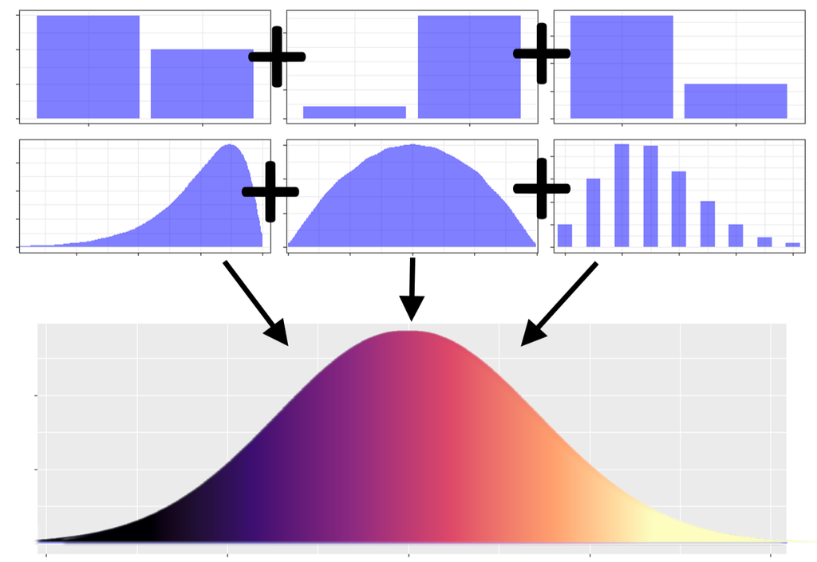

## tendency towards “normality”?

this is a **generalization of the Central Limit Theorem (CLT)** to the sum of (many) independent and identically distributed varaibles (*Lindeberg–Lévy CLT*) or even non-identically distributed variables (*Lyapunov CLT*)

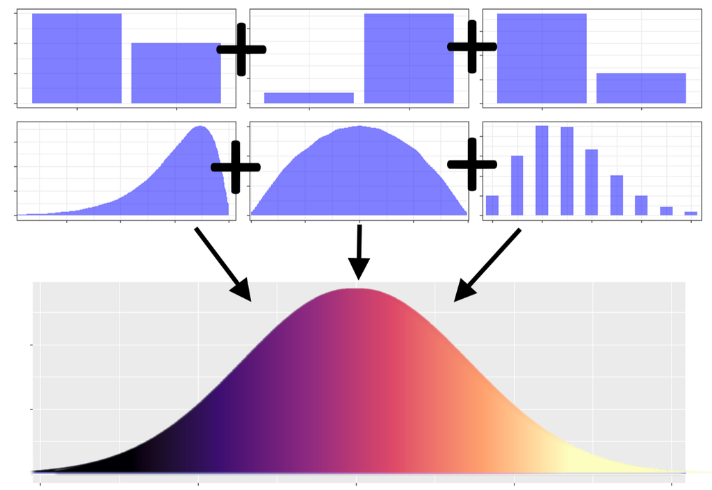

[figure not shown]

## but then, why are so many variables skewed?

in many (most) cases, observed scores are reflective of the underlying dimension of interest; but **we do not *directly* observe the dimension of interest**, we only observe scores that generally:

- are aggregate of non-normally distributed responses that may only approximate normality (e.g., sum scores from binomial/ordinal responses of a limited number of items)
- have a lower bound (e.g., zero for times, errors), *or*
- have both a lower and an upper bound (e.g., accuracies, sum scores)

## TIME

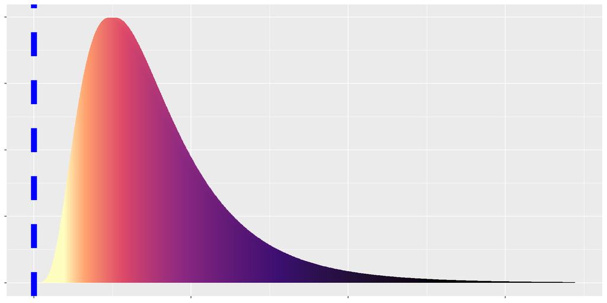

while the underlying ability of interest might be normally distributed, observed times cannot be, because they present a lower bound on zero

## TIME: mean vs variance

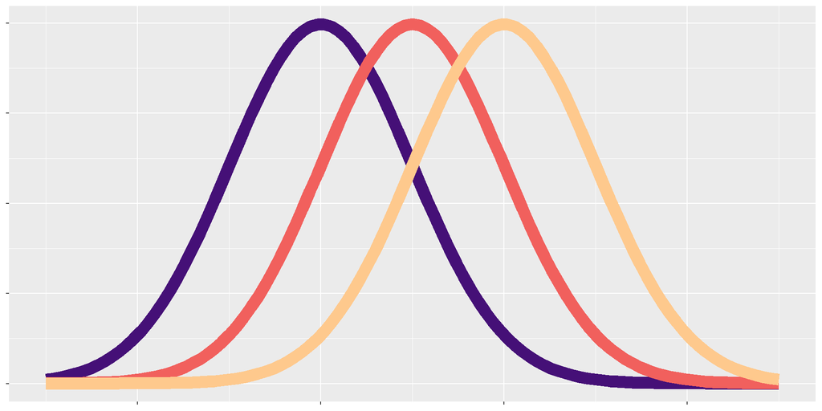

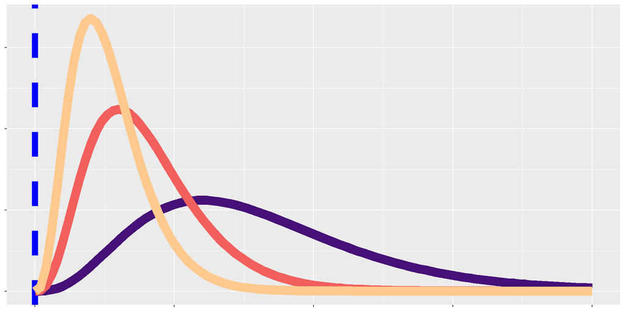

- *true underlying (maybe normally-distributed) scores*: experimental condition (or group) **purple** is more difficult (less able) than experimental condition (group) **orange** there is only a shift in mean value;
- *observed scores*: as *mean* increases, *variance* also increases
- the **LINK FUNCTION** links the *observed scores* to the *true underlying scores*; in the case above it is *logarithm* (`link="log"`; typical for times)

## ERRORS

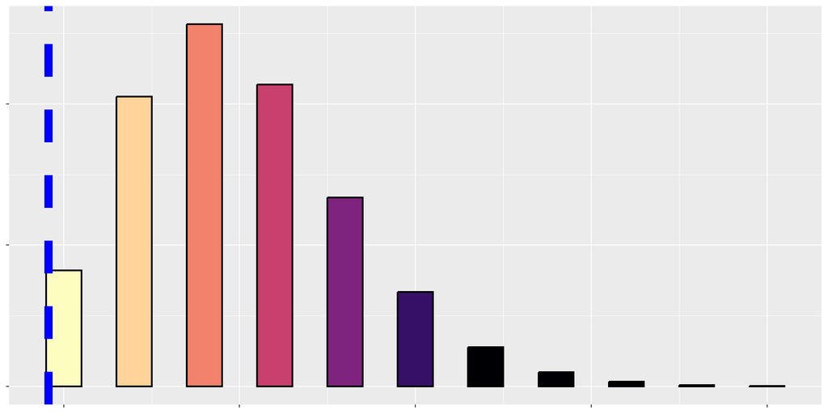

the case of error is very similar: a lower bound on zero again exists, with the difference that the observations are discrete (not continuous)

## ACCURACIES, BOUNDED SUM SCORES

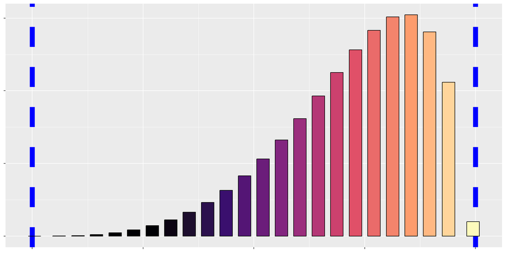

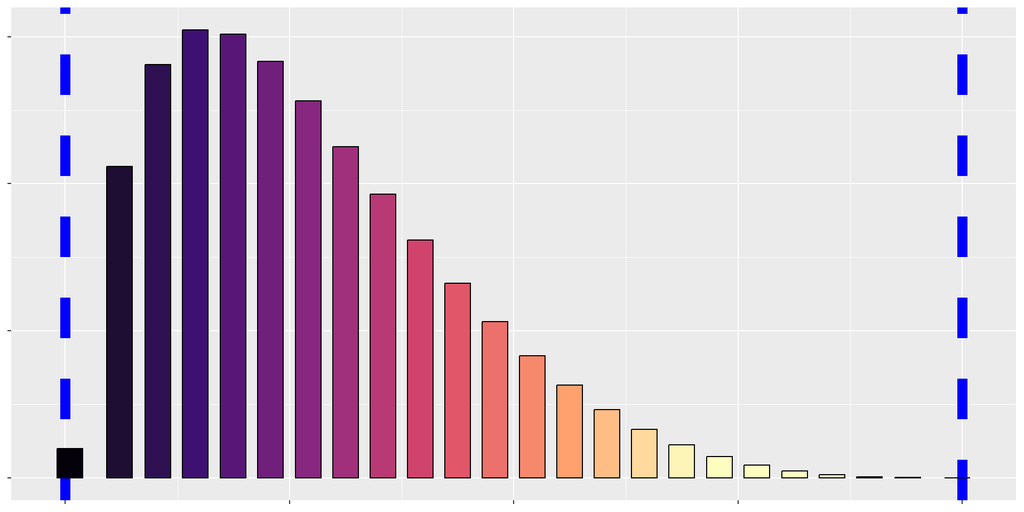

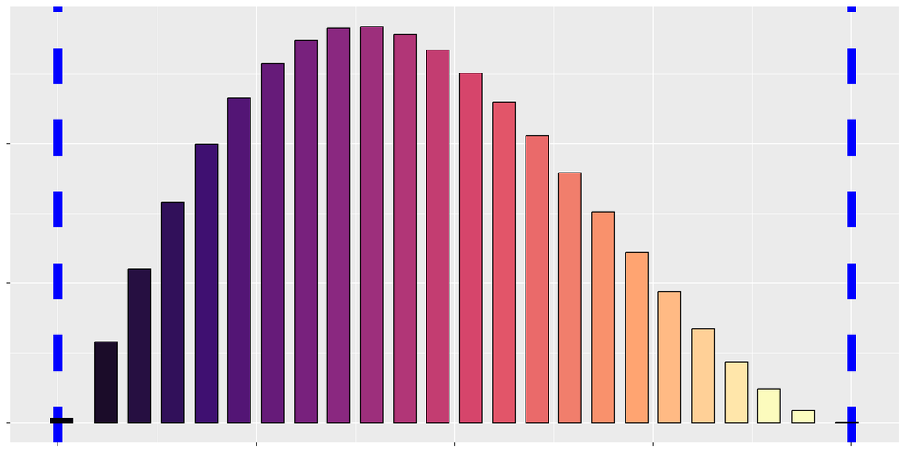

## `link = "probit"`

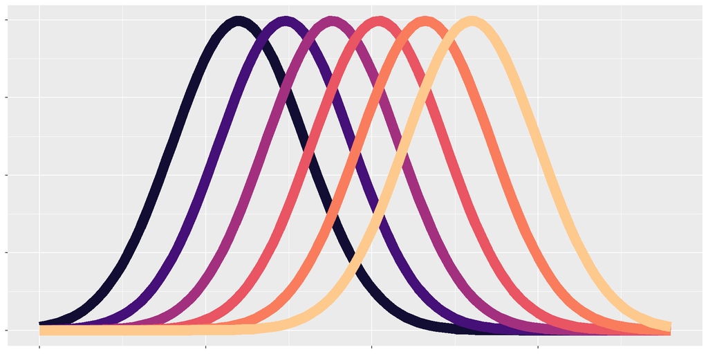

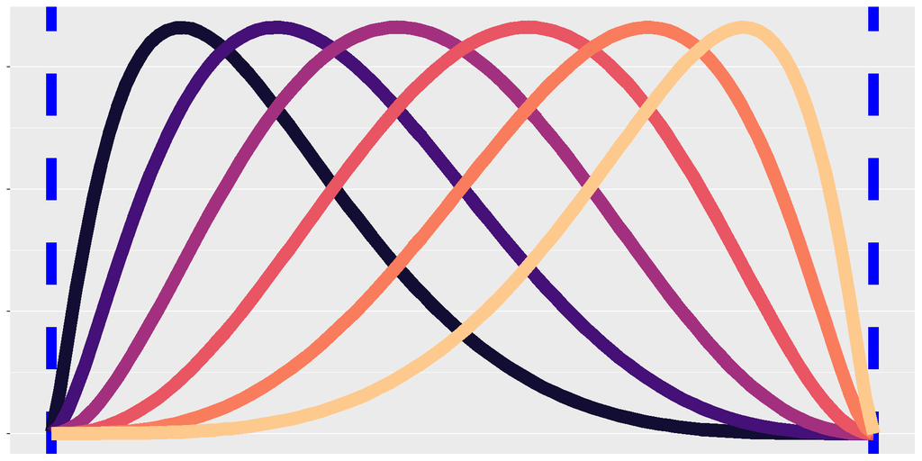

this is very typical of distributions arising from binomial processes (e.g., accuracies) but also ordinal processes (e.g., sum scores of scales, questionnaires)

*IMPORTANT: once again, note that equal intervals on the right panel do NOT reflect equal interval on the left panel*

## `binomial(link = "probit")`

In binomial and ordinal processes, even if underlying individual differences (random intercepts) are normally-distributed, observed sum scores may not be “normal”.

Accuracies or sum scores computed on 5, 10, 20 items must consider that the underlying data-generating process is binomial.

## Differences between differences

In all previous cases, we noted that *equal differences on the observed scores do NOT reflect equal differences on the underlying ability/trait*.

➜ This **may have devastating consequences when testing interactions**, because interactions can be seen as tests of whether there are *differences between differences* (i.e., whether a difference is equal to another difference)

Note that *the link function transforms equal intervals into unequal intervals*